# GlejakPartIII

Tomasz Wąs, Antoni Zawodny

5 grudnia 2016

Przeprowadziliśmy testy czterech modeli w oparciu o dane dotyczące przeżywalności pierwszego roku od zdiagnozowania glejaka. Były to regresja logistyczna, las losowy, xgboost i metamodel uwzględniający predykcję pozostałych trzech. W każdym z modeli brakujące dane zastępujemy średnimi wartościami dla danej zmiennej, opierając się na wszystkich dostępnych na ten temat danych, czyli zarówno całym zbiorze treningowym, jak i całym zbiorze testowym (dla którego nie mamy danych dotyczących śmiertelnośći).

# Regresja Logistyczna

Pierwszym modelem jest regresja logistyczna. Poprzez sukcesywne odrzucanie najmniej istotnych wskaźników, doszliśmy do modelu, w którym zmienna przeżywalności objaśniana jest za pomocą 6 zmiannych aktywności genów oraz wieku, gdzie każda zmienna jest istotna na poziomie istotności 5%. Wypracowana w ten sposób formuła jest następnie przez nas używana na zbiorach testowych bez wybierania istotnych zmiennych na nowo. W ten sposób wyniki, które otrzymamy mogą być lepsze niż te, które otrzymalibyśmy ucząc model od początku na każdej próbce testowej, jednak dzięki temu, model będzie bardziej stabilny w zależności od wylosowanej próbki. Poniżej znajduje się podsumowanie tego modelu:

```
##
## Call:
## glm(formula = fmla_logit, family = "binomial", data = d)
##
## Deviance Residuals:
##      Min        1Q    Median        3Q       Max
## -2.74608  -0.46434  -0.01743   0.59338   2.18389
##
## Coefficients:
##             Estimate Std. Error z value Pr(>|z|)
## (Intercept)  5.76240    1.92018   3.001  0.00269 **
## RASSF1      -3.15570    0.96075  -3.285  0.00102 **
## CSNK1D      -3.33690    1.16727  -2.859  0.00425 **
## FCRLB       -1.45810    0.46579  -3.130  0.00175 **
## IMMP2L      -1.16842    0.44849  -2.605  0.00918 **
## MYBPC2      -0.51423    0.18453  -2.787  0.00533 **
## NRG1        -0.44716    0.13947  -3.206  0.00135 **
## age         -0.06111    0.02775  -2.203  0.02762 *
## ---
## Signif. codes:  0 '***' 0.001 '**' 0.01 '*' 0.05 '.' 0.1 ' ' 1
##
## (Dispersion parameter for binomial family taken to be 1)
##
##     Null deviance: 173.279  on 124  degrees of freedom
## Residual deviance:  90.243  on 117  degrees of freedom
## AIC: 106.24
##
## Number of Fisher Scoring iterations: 6
```

Aby móc częściowo zobaczyć działanie modelu wyrysowaliśmy obaszary decyzyjne modelu, dla różnych aktywności dwóch genów uznanych przez model za naistotniejsze.

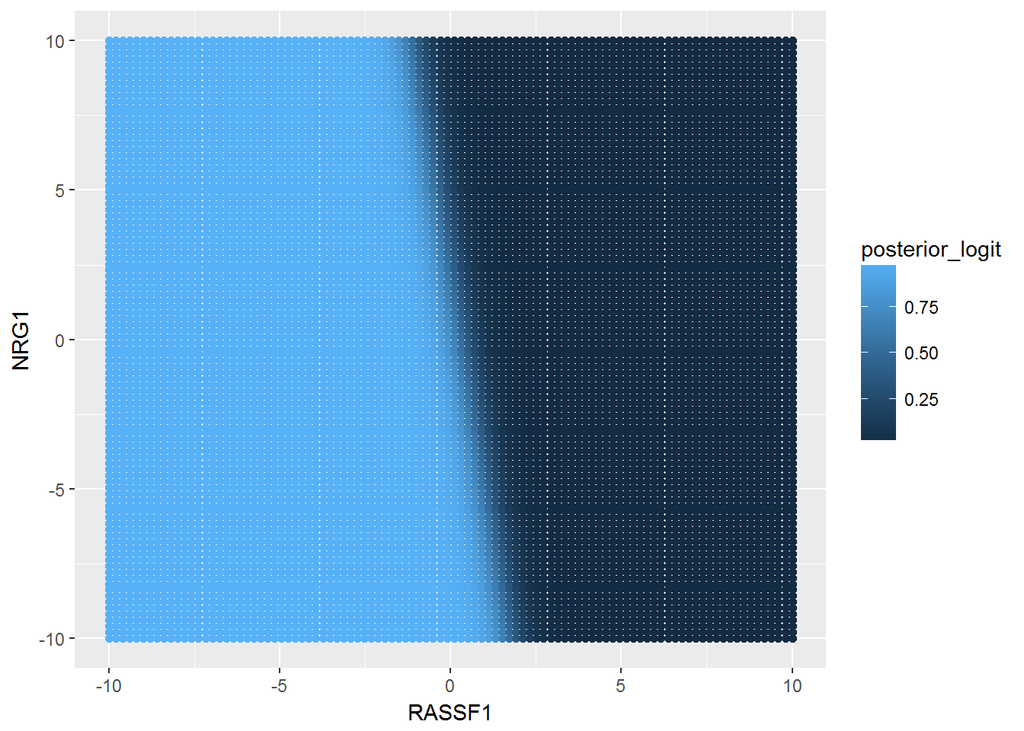

# Random Forest

Drugim rozpatrywanym przez nas modelem jest las losowy. Używamy go wykorzystując 1000 drzew i 23 zmienne testowane na przy każdym rozgałęzieniu. Poniżej znajduje się podsumowanie jego działania:

```
##
## Call:
##  randomForest(formula = fmla, data = d, importance = TRUE, proximity = TRUE,      ntree = 1000, mtry = 23, na.action = na.exclude)
##                Type of random forest: classification
##                      Number of trees: 1000
## No. of variables tried at each split: 23
##
##         OOB estimate of  error rate: 28.8%
## Confusion matrix:
##    0  1 class.error
## 0 43 20   0.3174603
## 1 16 46   0.2580645
```

Aby zobaczyć graficznie jak działa ten model postanowiliśmy wykorzystać drzewo odległości. Model sam determinuje jak ‘blisko’ według niego są poszczególne obserwacje i można to przedstawić za pomocą następującego drzewa. Czerwone kropki oznaczają pacjentów którzy nie przeżyli pierwszego roku, w przeciwieństwie do zielonych kropek. Czym bardziej oba kolory są od siebie wyraźnie oddzielone, tym model lepiej radzi sobie z poprawną klasyfikacją. Jak widać poniżej można wyróżnić duże grupy jednokolorowych punktów jednak, nie jest to idealna klasyfikacja.

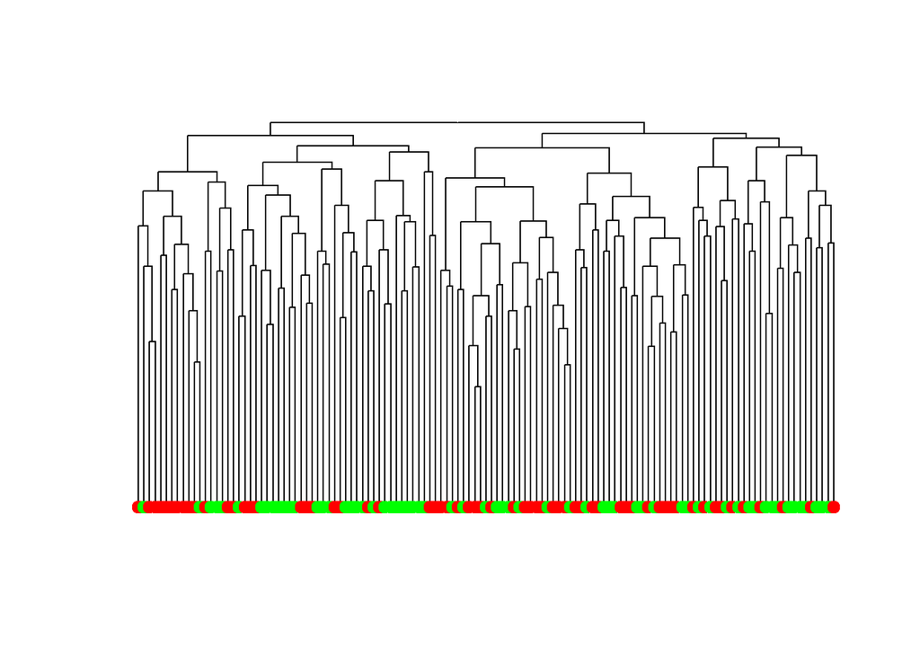

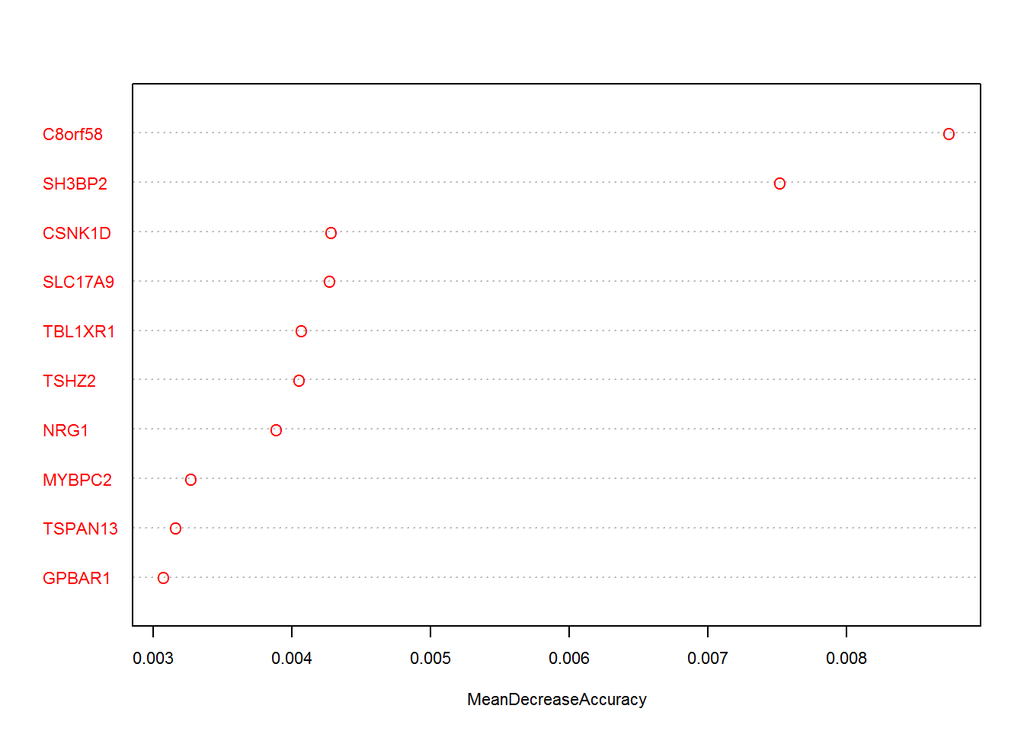

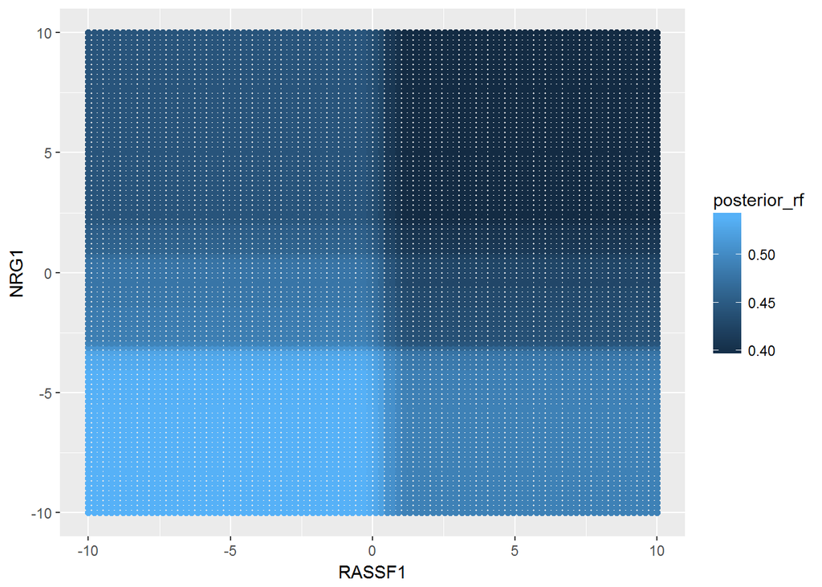

# XGBoost

Trzecim rozpatrywanym przez nas modelem jest xgboost z liczbą iteracji równą 100. Również dla tego modelu zrobiliśmy wykres jego obszarów decyzyjnych dla dwóch wybranych wcześniej genów.

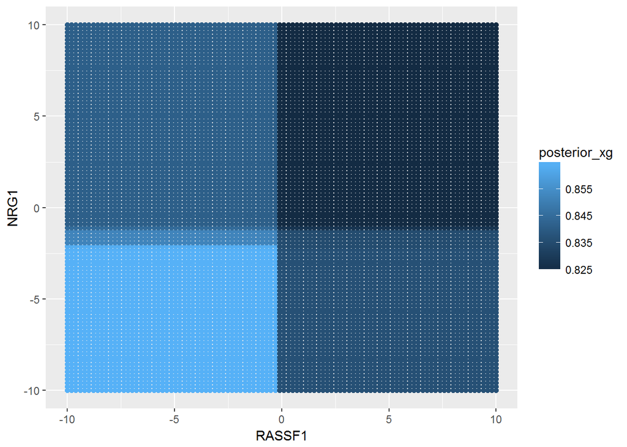

# Model Stacking

Czwartym rozpatrywanym przez nas modelem jest połączeniem trzech poprzednich. Ponieważ są one trzy, to dwa zawsze muszą wskazywać na ten sam stan pacjenta po roku, zatem w modelu tym uznajemy, że jest on właśnie taki.

# Porównanie modeli

40 razy wybraliśmy 100 osobową próbkę z wszystkich obserwacji dostępnego zbioru danych i przyuczyliśmy na niej wszystkie trzy modele. Następnie zliczyliśmy błąd średniokwadratowy predykcji na dopełnieniu tej próbki jak również, odsetek błędnie zakwalifikowanych pacjentów. Dla czwartego modelu policzyliśmy tylko ten drugi wskaźnik, ponieważ ten model nie zwraca prawdopodobieństw.

Błąd średniokwadratowy dla regresji logistycznej:

```
## [1] 0.1383049
```

Błąd średniokwadratowy dla lasu losowego:

```
## [1] 0.1652308
```

Błąd średniokwadratowy dla XGBoosta:

```
## [1] 0.2103136
```

Odsetek błędnych klasyfikacji dla regresji logistycznej:

```
## [1] 0.195
```

Odsetek błędnych klasyfikacji dla lasu losowego:

```
## [1] 0.266
```

Odsetek błędnych klasyfikacji dla XGBoosta:

```
## [1] 0.317
```

Odsetek błędnych klasyfikacji dla metamodelu:

```
## [1] 0.251
```

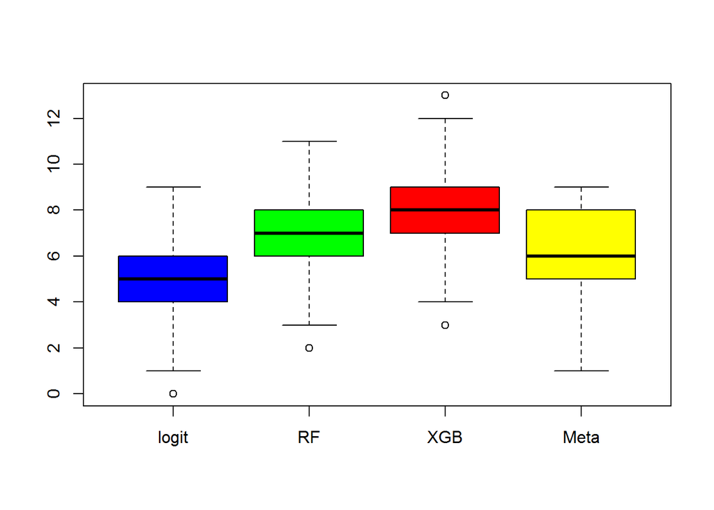

Ponieważ nasza ocena oparta jest na skuteczności zero-jedynkowej predykcji, uznaliśmy, że ważniejszy jest dla nas odsetek błędnie zakwalifikowanych danych. W związku z czym na podstawie tych wyników najbardziej obiecujący wydaje się model regresji logistycznej, w drugiej kolejności metamodel, a następnie las losowy.

```
##
## Call:
## roc.default(response = real_val, predictor = pred_glm, direction = "<")
##
## Data: pred_glm in 97 controls (real_val 0) < 103 cases (real_val 1).
## Area under the curve: 0.8888
```

```
##
## Call:
## roc.default(response = real_val, predictor = pred_rf, direction = "<")
##
## Data: pred_rf in 97 controls (real_val 0) < 103 cases (real_val 1).
## Area under the curve: 0.8193
```

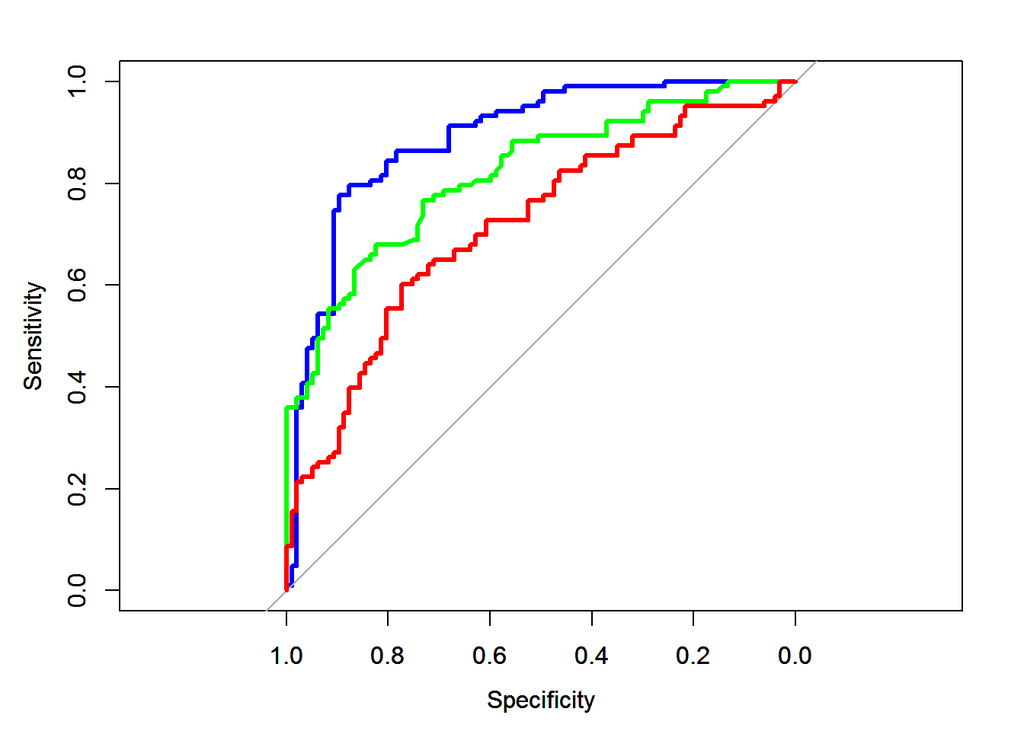

```
##
## Call:
## roc.default(response = real_val, predictor = pred_xg, direction = "<")
##
## Data: pred_xg in 97 controls (real_val 0) < 103 cases (real_val 1).
## Area under the curve: 0.7166
```